# Exploration of Ford GoBike system data (by Rodion Boriskin)

## Investigation Overview

Main purpose of investigation was discover following statistics:

- how distribution of renting period, distance, user ages, genders, contract types look like
- renting peaks and downs during the day and week
- undertanding correlation of user types (subscriber or customer) also gender with renting durations and frequences
- ratio between amount of rented and returned bikes at station (to understend if bike relocation process needed)

## Dataset Overview

This data set includes information about individual rides made in a bike-sharing system covering the greater San Francisco Bay area. Data was collected for Feb-2019 from 319 different renting statons.

## Visualization of period and distance distributions

#### * Both renting period and cycling distance distributions are skiwed to right

#### * Renting period is quete short 5-10 minutes. Some orders are up till 60 minutes.

#### * Cycling distance covers 500 - 2500 meters. There are few cases with long distance, similar to renting time.

#### * Also there is group of orders when bike was returned to the same station as it was rented (zero distance).

- Distance is calculated via geographical coordinates diffrence from start and ens stations

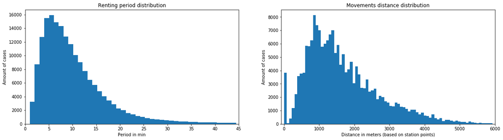

## Visualization of user ages, genders, contract types

#### * Main user for this service are young people in ages from 23 till 39. Howevwer there is no age limit in general

#### * Main users (71 %) are men. Wemen are only 22%. Reason to be clarified (ex. not convenient bike types, colors)

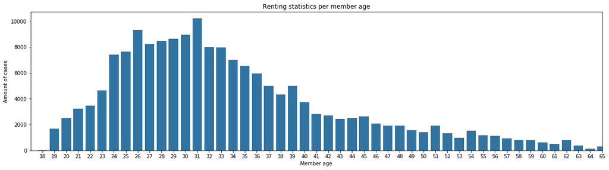

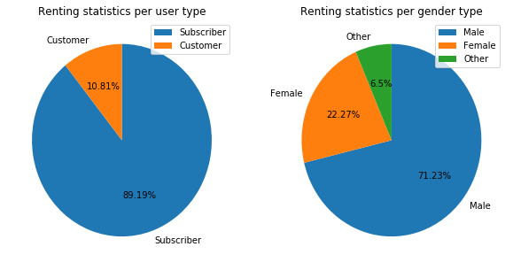

## Visualization of renting during weekdays and day hours

#### During working days mornings and evenings people use bikes to go to work (specific distance and time to cycle)

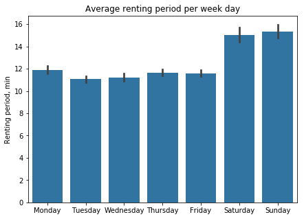

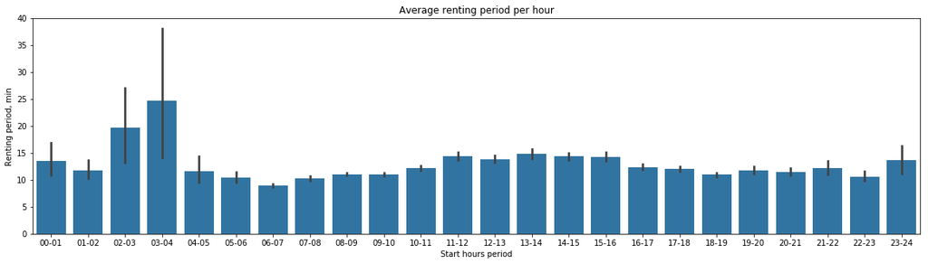

## Visualization of rent and return distribution

#### * At most of the stations amount of rentings and returns close to each other.

#### * However at some station there is disbalance, therefore redistribution is needed.

#### * List of stations shown below. Detailed reasons and frequency to be investigated separatelly.

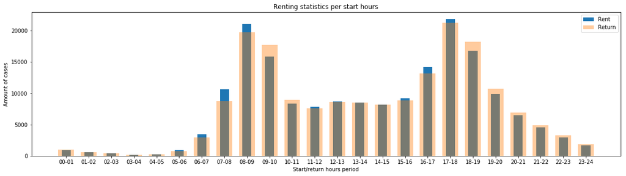

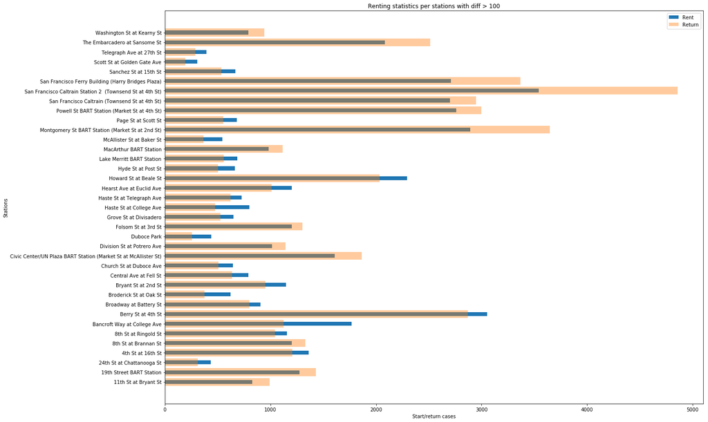

## Conclusion and recommendation

#### Idea 2:

As soon as level of Female orders many less than Male it needs to investigate reasons (may be byke types) to improve further total Female ratio.

#### Idea 3:

As soon as bike lacking issue (difference between rented and returned bikes) available for specific stations (37 with more then 100 bikes per month) proposed solution: to organize periodical redistribution or set some discounts for returning bikes to problematic stations.

## Thanks for yuor attention!